# 1.0 Why R is a Significant Tool of Choice for Epidemioligists

Ahmed Hifaz

05/01/2021

## KEY

- R-The programming language
- r-The indicator (Reproduction number)

## 1.1 Data Analytics & Epidemiology

- Data analysis is vital for epidemiological research, and It’s fair to claim that the advancement for epidemiological studies is as vital as the advancement of computers, due to the increasing discovery of new diseases and pandemics. (Virasakdi, 2012)

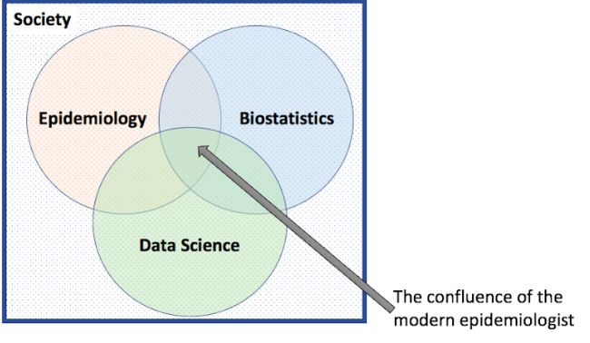

- There are a wide range of commercial statistical software packages available to the epidemiologists, however,the cost of these softwares prove to be substantially high, as a result, developing countries often tend to rely on pirated software copies. On the other hand,majority of the open source softwares consist of limited specifications.Foe example, though applications such as EpiInfo are open source, and useful for simple data analysts, advanced data scientists find the software unsuitable for data manipulation, regression analysis, multilevel modeling and advanced graphing. (Virasakdi,2012)
- R is an open source programming language utilized for the study of data analysis and programming, and makes upto some of the downsides of the commercial statistical package software. It follows an “open source software philosophy”. The use of R should be highly motivated for epidemiologists that are unable to afford expensive commercial software packages. (Aragon,2020)
- Though it’s challenging to learn how to use R, it has almost everything that an epidemiological data analyst needs. It has become one of the most preferred data analytic tools for pupils involved in professional fields such as mathematicians, public health analysts, and research epidemiologists. (Virasakdi, 2012)
- R is used to explore, analyze and interpret epidemiological data (Reports, Articles and tables), and is capable of quantitatively expressing, graphically exploring, and describing epidemiologic data. (Virasakdi 2012)
- R could be utilized as the following tools: (Aragon,2020)
1. Full Function calculator

[figure not shown]

2. Extensible statistical Package

[figure not shown]

3. High quality graphic tool

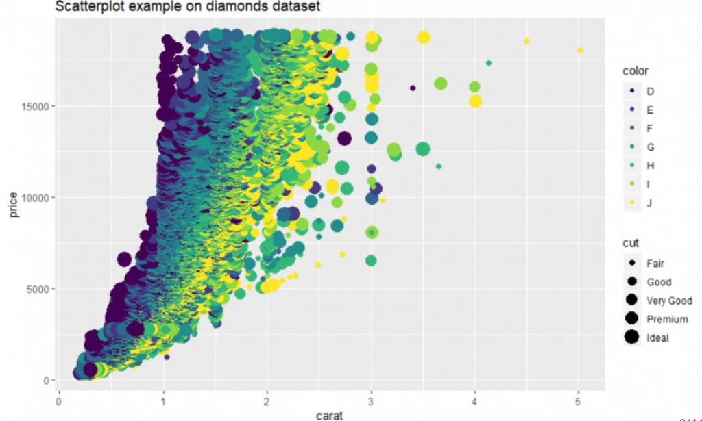

4. Multi purpose programming language

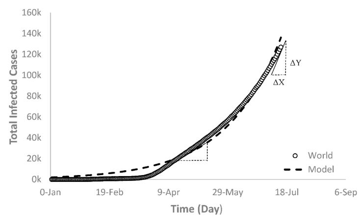

5. Matrices & Algebra

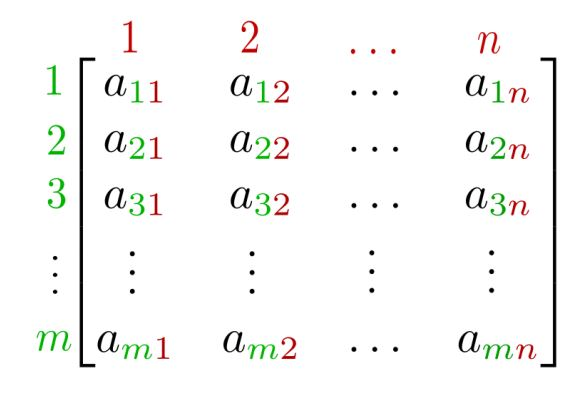

- The real advantage of R is its ability to manipulate, explore, and graphically display data with ease. Through the use of R, epidemiologists are capable of handling several datasets simultaneously: by copying it to the search path or by including the dataset name as a prefix.On the other hand, R supports highly powerful graphing functions, that could produce descriptive graphs, and be used to view the trend of the pandemic/epidemics over time, and to predict future trends (steep learning curve). (Aragon,2020)
- A handful range of statistical tools that epidemiologists use are made readily integrated to the program, such as the:
1. Cox proportional hazard regression

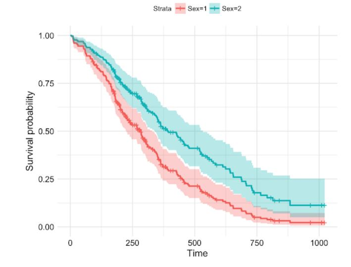

2. Unconditional logical regression

[figure not shown]

3. Poisson regression

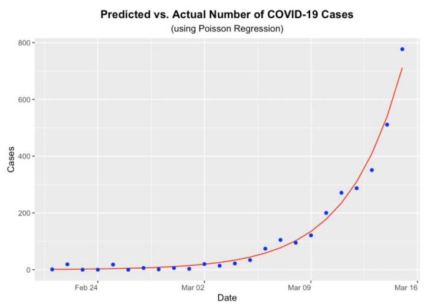

4. Survival analysis

[figure not shown]

5. Multilevel modeling

[figure not shown]

## 1.2 Role of “r” Number in COVID 19 Data Collection

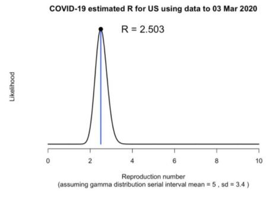

Source:RViews,2020

- Keep in mind: r is just one of the indicators (body counts, rate of infection) to undermine the degree of outbreak, and it’s prone to inconsistencies: Doesn’t provide real time data Represents only an average across a region (E.g. Bonn & Cologne might have different r numbers, but they are categorized under the state of “North Rhine Westphalia, and are given the same r number)
- The Key: If the r number is higher than 1, means the outbreak is growing rapidly!

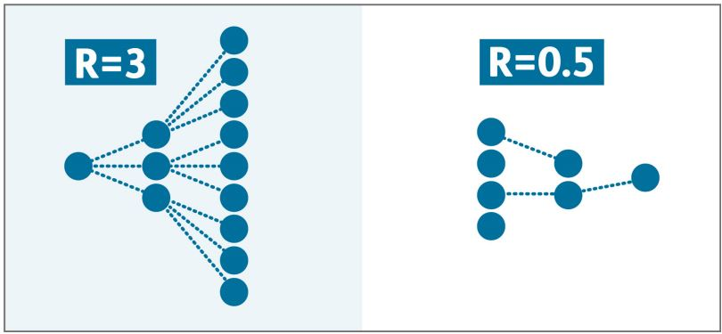

Webb,2020

## 1.3 Introducing RECON & RECON Learn Package

- Known as “R Epidemics Consortium”, is an international non profit & non governmental organization which gathers experts in fields such as; data science, modelling methodology, public health, and software development to create the next generation of analytics tools, in order to inform the mass on how to act in line with the calamities such as disease outbreaks, health emergencies, and humanitarian crisis. (Consortium.R,2020)
- The most fundamental RECON tools:Open source resources, fundamentally “R”
- RECON’s packages are specifically designed for handling, visualising, and analysing outbreak data using cutting-edge statistical methods, fulfilling three key aspects:

1)Efficiency-Real time information in order to improve awareness

2)Reliability-Tested and approved through professional software development methods

3)Accessibility-Openly sourced accessible tools, made available on virtually any platfrom.

- RECON Learn- Aims to give a few insights on some methodological aspects on outbreak analysis.
- Early outbreak contexts: days/weeks index, availability of limited data, limited intervention, rate of response. (Consortium.R, 2020)
- Data usually available: Data from past outbreaks, dates of death or recovery, dates of exposure, contact tracing (who infects who), and dates of symptoms.(Consortium.R,2020)
- Major dilemmas surrounding the infection:rate of growth, reason, fatality ratio, severely affected, expected cases within the coming weeks. Other factors centered around the issue: Population, samples (cases of covid reported within a certain period), statistics (fatalities), inference (E.g. Bavaria has the highest R number in Germany). (Consortium.R, 2020)
- Good statistical practices: Data is presented upon request, estimates and uncertainties are precisely shown, accounting for the variability in data. (Jombart,2019)
- A major area of concern for epidemioligits are to “estimate key delays”
1. The incubation period:Refers to the time interval between the date on infection and the date of symptom onset.

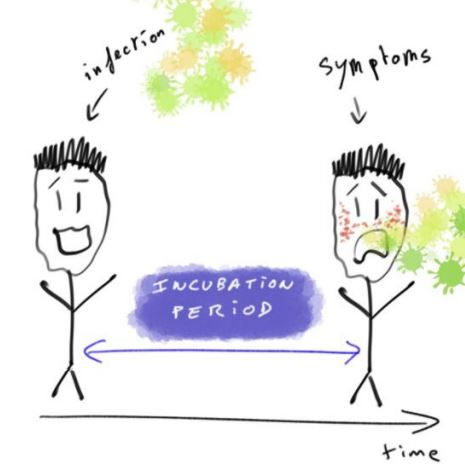

Source:Jombart 2019

2. The serial interval:Refers to the time interval between onset of symptoms in primary, and secondary cases.

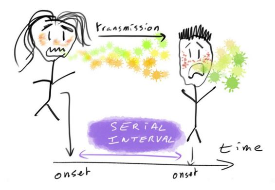

Source:Jombart 2019

3. The generation time: Refers to the time travel interval between date of infections in primary, and secondary cases.

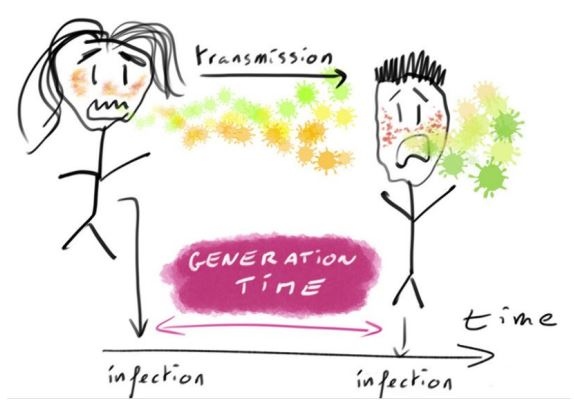

Source:Jombart,2019

## 1.4 Web Scraping & Data Coalition (Rviews,2020)

- Covid data isnt easy to read, and seems often encrypted (embedded) since it’s not written in a straightforward manner, rather written in counts. (E.g. recovered cases, deaths due to the virus, magnitude of affected people at a certain hotspot)
- Web Scraping: Is a technique used to extract a large magnitude of data from the website and store it in a local desktop in a table or spreadsheet format. Data provided in sites such as WikiPedia are well and straight forward, but are often challenging to scrape, since the data provided is against the constant (always changing). It’s not often suitable if you want insights of real time updates, and involves daily maintenance of your web scraping code. (E.g. Timing of COVID 19 Pandemic in China”)
- Since WikiPedia is crowdsourced, and anyone is authorized to add/edit information, it’s prone to inaccuracy, it’s important to refer to other sources in order to reach a legit conclusion. A notoriously collated use of data comes from “John Hopkins University Center” for system Sciences and Engineering, interestingly it’s also the source for real time data updates (From the dashboard)
- ALL TECHNOLOGY HAS CONSTRAINTS: Datasets from John Hopkins university consists of few missing data (Lagging time, few missing incidents).
- Early Packages aids data analysts to calculate the degree of early outbreak statistics, such as reproduction rate, and the number of cases that are expected to rise within a given period of time. (Maximum likelihood of reproduction)

## 1.5 Case Study: Saxony-Germany’s “Haunted State” (TheLocal,2020)

- Why is it important to have a detailed analysis of primary & secondary cases, and why did Saxony suffer a collateral damage during the second wave?
- The situation in the East German state of Saxony has suffered vigorously from the second wave, and hospitals are were in deep turmoil, due to limited bed capacities (It has to choose who gets access over the ventilators.). Saxony was under a state of a total lockdown, just as it’s neighbouring states within the nation.

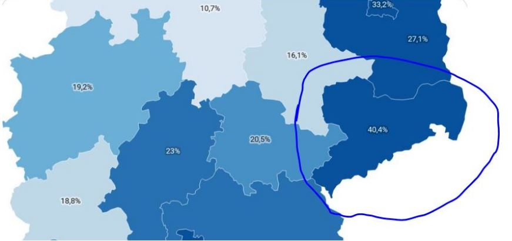

Source:TheLocal,2020

- This map shows the “Proportion of COVID-19 patients in the total number of intensive care beds”, as seen, the East German state of Saxony is the worst hit with 40.4% (with cases there now at over 400 per 100,000 inhabitants).
- The concrete reason for the rapid increase in the number of cases is still unknown, since data on where people have contracted the virus is still unknown. (It’s vital have an insight of the primary cases, secondary cases, and location of contraction in order to have a 360 degree analysis on the outbreak, and to stabilize)
- However, there are some theories regarding the rapid outbreak:

1)An aging population: The state has the oldest population in Germany, who are more likely to contract the virus, and infect one another in comparison to the youth.

2)Borders with Czech Republic and Poland: Geographically, Saxony shares its border with the Czech Republic, and Poland, thus making it accessible for them to travel to and from the state, with no obligatory testing required. Just like Saxony, the Central European country of Czech Republic has been hit hard by the second wave, since dropping the majority of it’s Corona restrictions in the summer. The cases in Czech Republic are progressing to increase. On the other hand, Poland has also seen similar circumstances, fortunately, the cases are falling in Poland under the current circumstances.

3)Hotspots in villages: The two big Saxonian cities (Dresden & Leipzig), haven’t been hit as hard as the rural areas and the countryside. Some epidemiologists claim that the reason for this is “carelessness” (Meeting friends, holding private gatherings at remote locations where authorities hold hardly any control.)

## List of References

Thelocal.de. 2020. [online] Available at: https://www.thelocal.de/20201221/analysis-why-has-saxony-been-hit-so-hard-by-the-winter-wave-of-the-coronavirus-pandemic?fbclid=IwAR3Os5dK7MCyMXslUzO6o6iDsJbGUg1Rv_xy0m0-Jl-M8slwB5l2hxPS_YE [Accessed 23 December 2020].

Consortium, R., 2020. R Epidemics Consortium. [online] Repidemicsconsortium.org. Available at: https://www.repidemicsconsortium.org/ [Accessed 23 December 2020].

Jombart, T., 2020. A Primer On Statistical Outbreak Analysis. [online] Reconlearn.org. Available at: https://www.reconlearn.org/slides/outbreak-statistics/outbreak-statistics.html#1 [Accessed 23 December 2020].

Aragón, T., 2020. Population Health Data Science With R. [online] Bookdown.org. Available at: https://bookdown.org/medepi/phds/getting-started-with-r.html [Accessed 31 December 2020].

Virasakdi Chongsuvivatwong. and McNeil, E., 2012. Analysis Of Epidemiological Data Using R And Epicalc. Songkla: Epidemiology Unit, Prince of Songkla University.

Views, R., 2020. COVID-19 Epidemiology With R. [online] Rviews.rstudio.com. Available at: https://rviews.rstudio.com/2020/03/05/covid-19-epidemiology-with-r/ [Accessed 23 December 2020].

Sky News. 2020. Coronavirus: Why The Government Will Anxiously Look At The R Number As Lockdown Is Eased. [online] Available at: https://news.sky.com/story/coronavirus-why-the-government-will-anxiously-look-at-the-r-number-as-lockdown-is-eased-11985811 [Accessed 23 December 2020].